# Disentangling the influence of water limitation and simultaneous above and belowground herbivory on plant tolerance and resistance to stress - Mundim - 2021 - Journal of Ecology - Wiley Online Library

[Journal of Ecology](https://besjournals.onlinelibrary.wiley.com/journal/13652745)

[Volume 109, Issue 7](https://besjournals.onlinelibrary.wiley.com/toc/13652745/2021/109/7) p. 2729-2739

RESEARCH ARTICLE

Full Access

# Disentangling the influence of water limitation and simultaneous above and belowground herbivory on plant tolerance and resistance to stress

[Fabiane M. Mundim](https://besjournals.onlinelibrary.wiley.com/action/doSearch?ContribAuthorRaw=Mundim%2C+Fabiane+M),

[Ernane H. M. Vieira-Neto](https://besjournals.onlinelibrary.wiley.com/action/doSearch?ContribAuthorRaw=Vieira-Neto%2C+Ernane+H+M),

[Hans Alborn](https://besjournals.onlinelibrary.wiley.com/action/doSearch?ContribAuthorRaw=Alborn%2C+Hans),

[Emilio M. Bruna](https://besjournals.onlinelibrary.wiley.com/action/doSearch?ContribAuthorRaw=Bruna%2C+Emilio+M),

First published: 10 May 2021

https://doi.org/10.1111/1365-2745.13684

Check for Full Text

**Handling Editor:** Tobias Züst

## Abstract

1. Plants face multiple biotic and abiotic stressors simultaneously. Many species can tolerate and resist stress, but countermeasures differ between roots and leaves. Since herbivores and environmental conditions modulate costs and benefits of plant defence traits, stress responses are context-dependent. We examined whole-plant tolerance and resistance responses to individual and combined effects of above and belowground herbivory under variable water conditions.
2. We manipulated water availability and access by two common herbivores (*Spodoptera* *exigua* caterpillars and *Meloidogyne incognita* nematodes) to *Solanum lycocarpum*. Plants were either watered based on historical regional averages or the 30% reduction predicted by IPCC studies. Herbivory treatments included isolated above (AG) and belowground (BG) attacks, simultaneous (AGBG) attacks and no-herbivory controls. We then parameterized generalized linear mixed-effects models with data on plant survival, leaf and root biomass accumulation, root complexity and terpenoid concentration.
3. Foliar herbivory increased terpenoid concentrations in roots relative to no-herbivory plants under control water but decreased concentrations in both roots and leaves under drought. Similarly, root feeders increased concentrations of terpenoids in leaves under control water but decreased concentrations only in roots under drought. Plants challenged with AGBG herbivory had greater whole-plant biomass (i.e. tolerance) and lower total concentrations of defensive compounds (i.e. resistance) than plants exposed to no-herbivore controls, regardless of water conditions. Importantly, the capacity of plants to grow or produce terpenoids changes when herbivory level is considered. In plants exposed to AGBG herbivory, greater nematode infection was related to decreases in whole-plant biomass and marginal increases in total terpenoid concentration. Ultimately, accounting only for individual AG and BG responses would have led to different conclusions and underestimated the magnitude of *S. lycocarpum*'s compensatory responses. A ‘whole-plant’ approach revealed that belowground herbivory is the primary driver of tolerance in plants surviving moderate water stress.
4. *Synthesis*. Whole-plant responses to stress in variable environments are complex, and their comprehensive understanding requires accounting for belowground herbivores and root responses.

## 1 INTRODUCTION

Plants are often simultaneously attacked by multiple herbivore species, and the damage they cause can negatively affect plant performance. One way in which plants offset the negative effects of herbivory on fitness is via tolerance, which is the ability to withstand damage without fitness loss (Belsky, 1986) or respond to it with elevated growth and reproduction (Fornoni, 2011; Strauss & Agrawal, 1999; van der Meijden et al., 1988). Plants can also confront consumers by using physical and/or chemical defences to reduce herbivore preferences or performance (Agrawal & Fishbein, 2006; Karban & Baldwin, 1997; War et al., 2012). Both strategies incur potential costs to plants, including altered patterns of nutrient allocation, reduced resistance to pathogens, delayed or limited reproduction (Mundim et al., 2012; Neilson et al., 2013; Siemens et al., 2003, 2010; Stevens et al., 2007), and changes in traits associated with alternative anti-herbivore strategies such as escape (Karban & Baldwin, 1997; Agrawal, 2000; Agrawal & Fishbein, 2006). The magnitude of these costs can be modulated by herbivore identity, amount of damage and local abiotic conditions (Strauss et al., 2002)—factors that can also exert strong selective pressures on plant defensive traits (Herms, 1999; Huot et al., 2014; Tiffin, 2000).

A central tenet of many theoretical frameworks for studying tolerance is that plants in low-stress and resource-rich environments can tolerate herbivory better than those in high-stress locations with limited water, light or nutrients (e.g. Coley et al., 1985; Herms & Mattson, 1992; Wise & Abrahamson, 2005). Plants which overcompensate (i.e. regrow more than what was lost) after drought stress are expected to suffer physiological changes (e.g. less robust leaves with lower dry mass per area, lower investment in secondary defences) that can penalize future growth and reproduction, and be more vulnerable to biotic attacks (McKiernan et al., 2016). Counter-intuitively, studies have shown an inverse association between drought stress and costs of plant tolerance (English-Loeb et al., 1997; Hawkes & Sullivan, 2001; Seki et al., 2007). Plants undergoing water deficiency can switch to a ‘stress mode’ that leads to changes in photosynthesis and root phloem metabolics (Fàbregas et al., 2018). Plant tolerance costs are thus determined by how a plant efficiently and timely senses stress and adopts strategies to overcome resource-limited conditions. There is also no clear trend in how plant defences respond to drought stress (Holopainen et al., 2018; Mundim & Pringle, 2018), with studies finding decreases (McKiernan et al., 2014), increases (Blanch et al., 2008; Nogués et al., 2014; Podda et al., 2019) and no change (Gerson & Kelsey, 2004) in defences. Ultimately, the notion that plants tolerate herbivory while in resource-rich conditions or produce defences in poor-resource areas appears to be overly simplistic or even misleading.

The mismatch between theoretical predictions and empirical observations may be due in part to how frameworks initially account for the dynamic biotic and abiotic environment in which plants are embedded. Because plants are often simultaneously attacked by multiple herbivore species, empirical tests of tolerance have been expanded to consider how water limitation shapes tolerance to individual and synergistic effects of multiple consumers. However, most tests focus exclusively on aboveground herbivory and the resulting aboveground plant responses, overlooking the ubiquitous community of underground herbivores and their often large impact on plant growth, performance and survival (e.g. Barber et al., 2011; Maron, 1998). For example, it has been recently shown that drought promotes root herbivory by increasing the number of root-feeding nematodes (Franco et al., 2019). Although studies comparing plant responses to both above- and belowground herbivory remain rare, there is increasing evidence that countermeasures to damage differ between roots and leaves (Johnson et al., 2016; Mundim & Pringle, 2018). Defensive responses to belowground damage can also extend aboveground and vice-versa, with consequences for both plants and the herbivores in each location (Huber et al., 2016; Mundim et al., 2017; Wurst & van der Putten, 2007; Wurst et al., 2008). Finally, the extent to which plants can tolerate belowground herbivory (i.e. root damage)—both in isolation and in concert with aboveground damage—remains poorly understood, as does how this tolerance might be influenced by resource levels. Collectively, this suggests our current knowledge of plant responses to stress is incomplete, and that a more comprehensive understanding of tolerance and resistance as systemic defensive strategies requires a ‘whole-plant’ perspective.

In light of these gaps in our knowledge, and to understand the effects of multiple stressors on whole-plant tolerance and resistance, we examined plant responses to the individual and combined effects of above and belowground herbivory under variable water conditions. First, we predicted that conclusions regarding tolerance and resistance to herbivory would differ if above and belowground processes and responses were considered separately, collectively or in concert with water availability. For a plant, possessing both high tolerance and resistance to herbivory would seem redundant and be expected to result in high levels of growth and defences in the absence of abiotic or biotic pressures (e.g. enemy- and drought-free conditions) (Leimu & Koricheva, 2006; Ramula et al., 2019). However, as plants normally face multiple stressors under natural conditions, allocation costs—those associated with turning resources away from growth towards defences—should be balanced when both leaves and roots are under attack. Costs are expected to be higher for plants growing under limited water conditions. As drought reduces nutrient uptake and limits resource production and access (Bechtold & Field, 2018), more frequent or intense drought periods are expected to alter plant physiology and metabolic pathways (Bechtold & Field, 2018; Seki et al., 2007), likely constraining investments in resistance.

Second, we predicted that belowground herbivory is relatively more important than aboveground herbivory as a driver of plant tolerance (regrowth) under simultaneous attacks, but that this is only revealed with a ‘whole-plant’ perspective. Roots are responsible for resource uptake and storage, and act as sensors for water-deficit conditions (Brunner et al., 2015; Carvalho & Foulkes, 2018). In drought conditions, root growth takes precedence over leaf growth (Brunner et al., 2015). Moreover, belowground herbivores such as *Meloidogyne* nematodes obtain nutrients originally destined to aboveground parts (Kaplan et al., 2011). Since plants are governed by root–shoot relationships (Bonifas & Lindquist, 2006), it is essential to compare simultaneous above and belowground herbivore effects on the same plant in order to correctly understand their relative importance. We tested these predictions using shadehouse experiments with the tropical shrub *Solanum lycocarpum* (Solanaceae) and two of its common herbivores: *Spodoptera exigua* caterpillars and the nematode *Meloidogyne incognita*.

## 2 MATERIALS AND METHODS

### 2.1 Study system

*Solanum lycocarpum* (Solanaceae) is a common perennial, deciduous and pioneer shrub in South America's savanna woodlands (Lorenzi, 2002) such as Brazil's Cerrado. Commonly known as ‘lobeira’ or ‘wolf's apple’, these plants inhabit open vegetation physiognomies as well as disturbed areas such as abandoned pastures and roadsides. Leaves are protected by trichomes and thorns (Lorenzi, 2002), whereas roots, leaves and fruits contain terpenoids and alkaloids (e.g. Dall’Agnol & von Poser, 2000; Sá et al., 2000). Armyworm larvae (*Spodoptera* *exigua*) are common generalist leaf herbivores of *S. lycocarpum* in natural areas, as well as an important pest for other agricultural *Solanum* species such as tomatoes and egg-plants (Liburd et al., 2000). The roots of many *Solanum* species, including *S. lycocarpum*, are damaged by the root-knot nematodes *Meloidogyne incognita*, an endogenous generalist sedentary root-feeder that infects species from a broad spectrum of plant families (Shurtleff & Averre, 2005). *M. incognita* migrates through the soil and burrow into roots, where they form large galls, highly specialized feeding structures to support root-knot nematode development and reproduction (Shurtleff & Averre, 2005). These nematodes are severe threats to many crops, causing considerable yield and economic losses worldwide (Forghani & Hajihassani, 2020).

### 2.2 Experimental design

Seedlings were grown under the water treatments for acclimatization until February 2014 (~170 days). After adjusting to the new water conditions, we randomly assigned approximately *n* = 10 of the surviving plants from each water treatment to one of four herbivory treatments: aboveground herbivory (AG), belowground herbivory (BG), above- and belowground herbivory (AGBG), or no-herbivory, and randomly arranged them in the shadehouse. Since roots exhibit great plasticity in response to environmental changes, we measured structural features that could influence plant tolerance. For this, we set aside *n* = 15 randomly selected seedlings to record their total root length and spread (root complexity). Afterwards, we recorded the dry weight of their roots and leaves.

On 20 February 2014, plants in the AGBG and BG treatments were inoculated with 10 ml of water containing *c*. 5,000 M. *incognita* eggs; this solution was delivered with a pipette to three points around the roots (Bonetti & Ferraz, 1981). The root-knot eggs were obtained from a colony maintained in *Impatiens walleriana* at the UFU's Department of Agronomy Nematology Research Lab. The number of eggs with which we inoculated plants was ~50% of the amount present in the soil surrounding naturally occurring *Solanum lycocarpum* seedlings (F. Mundim, unpublished data).

Root-knot nematodes take up to 10 days to develop, emerge from the egg (infective J2 stage), migrate, and infect roots (Shurtleff & Averre, 2005). We therefore began aboveground herbivory on 2 March 2014 so that all above and belowground herbivory began on approximately the same date (Mundim et al., 2017). One second instar or later *Spodoptera* *exigua* larva was placed on a leaf of AG and AGBG treatment plants until it consumed 10% of total leaf area. We repeated this herbivory treatment every 10 days to ensure a continuous induced defensive response comparable to the continuous BG infection (see Mundim et al., 2017). Plants in the no-herbivory treatment were not exposed to any leaf or root herbivores. The manipulation of herbivory and water continued for 130 days, during which the nematodes had at least three cycles of reproduction and caterpillar leaf damage occurred at least 12 times. Over the course of the experiment (300 days) plants were not reproductive. We surveyed plants daily to record individual mortality and rotated them weekly to random positions in the shadehouse to avoid spatial effects.

In June 2014, 10 days after the last leaf damage by caterpillars, all surviving plants were removed from the soil and washed. Leaves, stems and roots were then separated. To infer leaf replacement after caterpillar damage, we measured the leaf damage cumulative leftover (the summed percentage of caterpillar damage remaining after all events of AG herbivory; see Appendix 2 in Supporting Information). We also measured the total root length and complexity using the software package ImageJ (Rasband, 1997). We used the centripetal link based ordering system to quantify the topological complexity of the root system (see Berntson, 1997). The total number of nematode galls were counted. Plants were dried and weighed for calculation of the total final biomass above and belowground. Dried roots, stems and leaves were then stored separately in paper bags for subsequent chemical analyses (see Jiang et al., 2016; Lakshmi et al., 2017).

Control data for root length and architecture, as well as leaf and root dry biomass and terpenoid concentration (non-herbivory, AG herbivory and BG herbivory under control water) were originally presented in Mundim et al. (2017).

### 2.3 Plant defensive chemistry

*Solanum* species have broad profiles of terpenoids in leaves and roots (War et al., 2012), but we have previously found that sesquiterpenes present the most treatment-dependent variation between plant parts (see Mundim et al., 2017). We therefore used the concentration of root and leaf sesquiterpenes and oxygenated sesquiterpenes as a metric of plant chemical responses to herbivory. We used an Agilent 7890A gas chromatogram (GC) combined with a G7000B mass spectrometry (MS) in electron impact and single quad mode for the GC/MS analyses. A general sesquiterpene section of the chromatogram was assigned between 14 tand 20 min retention time (RT) by sesquiterpene specific extracted ion chromatograms (molecular ion at m/z 204) prepared of a subset of the chromatogram. We used e-b- caryophyllene as standard to estimate sesquiterpene quantities based on peak area. As described in Mundim et al. (2017), a combined total ion peak area was used for the quantitative estimates after that background, random and noise peaks had been eliminated. Although we were able to identify some peaks (see Table S1), this process of summarizing eliminated the need to identify and re-assign individual peaks in varying and complex chromatographic profiles. For further details regarding the chemical analyses see Appendix 3 in Supporting Information.

### 2.4 Statistical analyses

We used R v3.6.1 (R Core Team, 2019) for all analyses and the *emmeans* function in the emmeans package (Lenth et al., 2019) for Tukey's *post-hoc* multiple pairwise comparisons.

We evaluated the effects of water availability, above- and belowground herbivory, and their interaction on survival of *Solanum lycocarpum* plants using a Weibull regression model. The survivorship (0 or 1) at *N* observation days of plants in the different treatments was calculated and compared using the *survreg* function from the survival package (Therneau et al., 2018).

We determined how water and herbivory treatments influenced the total final dry weight (g) of leaves and roots of *Solanum lycocarpum* using linear mixed-effects models via the *lme* function (Bates et al., 2015) in the nlme package (Pinheiro et al., 2016). The main effects were a combination of water treatments (control and drought), herbivore treatments (no-herbivory, AG herbivory, BG herbivory and AGBG herbivory), plant part (leaves and roots) and their interaction. The random effects attributable to variation among individual plants were included by treating each plant as a split-plot, with the combined water and herbivory treatments as whole-plot treatment and the location of measurements (i.e. roots, leaves) as the within-plot treatment (Mundim et al., 2017).

For root architecture and plant defensive chemistry, we tested the effect of water and herbivory treatments on root complexity, root length and whole-plant final concentration of terpenoids. The terpenoid concentrations were square-root-transformed to improve model fit. We used generalized linear mixed-effects models via the *glmmTMB* function (Magnusson et al., 2019), assuming a normal distribution for root length and terpenoid concentration, and a Poisson distribution for root complexity. Water treatment, herbivory treatment and their interaction were treated as fixed effects. We used Spearman's rank correlations to evaluate the relationship between terpenoid concentration and final biomass of leaves and roots under control and drought conditions.

Finally, we determined the extent to which simultaneous above and belowground herbivory affected plant tolerance and resistance, as well as their relative importance, by accounting for herbivory level (i.e. quantity) effects on plant biomass and terpenoid concentration. We used ANCOVA to analyse how the amount of nematode infection (number of galls per dry weight (g) of roots) and leaf damage cumulative leftover (summed percentage of caterpillar herbivory over time) affect whole-plant biomass and terpenoid concentration between water treatments for the different herbivory treatments.

## 3 RESULTS

### 3.1 Plant survival

Of the original *n* = 218 experimental *Solanum lycocarpum* plants, 52.3% (*n* = 114) died over the course of the 300-day experiment, with 38.53% of the mortality occurring in the first 35 days of water manipulation (Figure 1). Survival was lower in plants under drought than in those exposed to control levels of water (*χ*<sup>2</sup> = 94.15, *df* = 2, *p* < 0.001). Herbivory alone decreased survival (*χ*<sup>2</sup> = 24.94, *df* = 4, *p* < 0.001). Similarly, herbivory combined with drought decreased survival (*χ*<sup>2</sup> = 59.03, *df* = 14, *p* < 0.001), but water-limited plants exposed to BG or AGBG herbivory survived 60% and 20% less, respectively, relative to no-herbivory and AG herbivory treatments (Figure 1B). Water limitation was the main factor decreasing survival, and root herbivory amplified its deleterious effect (Figure 1B).

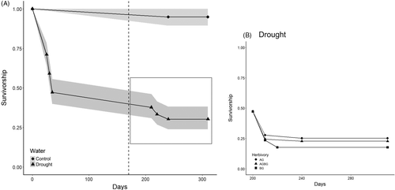

**FIGURE 1**

### 3.2 Plant biomass allocation

Experimental drought and herbivory had complex and generally contrasting effects on final biomass of *S. lycocarpum* plants. Drought decreased biomass overall, while the plant response to herbivory was context-dependent (Figure 2; Table S2). Aboveground herbivory resulted in a strong decrease in root biomass under control water (Figure 2C), but a slight increase of leaf and root biomass under drought conditions (Figure 2B and D, respectively). Belowground herbivory resulted in increased root biomass regardless of water conditions, while combined AGBG herbivory resulted in the highest biomass gain in both water treatments (Table S2). In fact, plants in the AGBG treatment could almost entirely compensate for the drought effect and only weighed 10% less than AGBG control plants (Figure 2; Table S2).

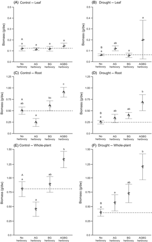

**FIGURE 2**

Herbivore impact on plant biomass (mean ± *SE* of final plant weight in g dw) in control water conditions (left column) and drought conditions (right column) for leaves (A and B), roots (C and D) and the whole-plant (E and F). In these scenarios, tolerance (dashed lines) is determined not only by resource (water) availability, but also by herbivore type, herbivory location (AG or BG) and if it occurs in more than one plant part. Values above the dashed lines are considered overcompensation, while those beneath represent undercompensation. Leaves and roots are represented by their dry weight, while the whole-plant is represented by the dry weight of leaves, roots and stem. Herbivore treatments consisted of: no-herbivory; single herbivory: AG (leaf only) or BG (root only); simultaneous herbivory: AGBG (leaf and root attacks). Lower case letters are differences between herbivory treatments while uppercase letters are differences between water treatments (without herbivory stress). Different letters indicate significant differences among treatments (*p* < 0.05) based on post hoc Tukey's tests

### 3.3 Root architecture

Water stress decreased root complexity and root length (*Z*<sub>1,10</sub> = −2.65, *p* = 0.008; *Z*<sub>1,10</sub> = −2.67, *p* = 0.007; see Controls in Table 1). Root herbivory (BG and AGBG) increased complexity and marginally increased length, while leaf (AG) herbivory decreased root complexity but did not change length (Table 1; Table S3). Drought-stress in concert with herbivory had a greater effect on root complexity than they did in isolation, while herbivory was the factor with the greatest impact on root length (Table S3).

TABLE 1. Root complexity, and total final root length (cm), of *Solanum lycocarpum* plants exposed to treatments of decreased and control water, as well as of aboveground herbivory (AG), belowground herbivory (BG), simultaneous herbivory (AGBG) and no-herbivory. Measurements occurred after 300 days of experimentation. Lower case letters are differences within an herbivory treatment while uppercase letters are differences between precipitation treatments (without the herbivory stress), based on Tukey's post hoc comparisons (*p* < 0.05)

|  | Root complexity<sup>1</sup> | Total final root length (cm) |
| --- | --- | --- |
| Decreased water treatment |  |  |
| No-herbivory | 25.45 ± 2.94<sup>abA</sup> | 173.99 ± 18.83<sup>aA</sup> |
| AG herbivory | 12.0 ± 3.18<sup>b</sup> | 185.42 ± 35.31<sup>a</sup> |
| BG herbivory | 37.42 ± 7.75<sup>ac</sup> | 250.97 ± 76.45<sup>ab</sup> |
| AGBG herbivory | 47.78 ± 9.51<sup>c</sup> | 329.6 ± 61.56<sup>b</sup> |
| Control water treatment |  |  |
| No-herbivory | 31.5 ± 3.74<sup>abB</sup> | 237.55 ± 16.44<sup>aB</sup> |
| AG herbivory | 18.10 ± 4.11<sup>b</sup> | 244.14 ± 35.87<sup>a</sup> |
| BG herbivory | 49.33 ± 9.22<sup>ac</sup> | 320.92 ± 47.38<sup>a</sup> |
| AGBG herbivory | 58.11 ± 9.42<sup>c</sup> | 336.64 ± 34.42<sup>a</sup> |

- <sup>1</sup> For root complexity, we used the centripetal link-based ordering system (see Mundim et al., 2017).

### 3.4 Plant defensive chemistry

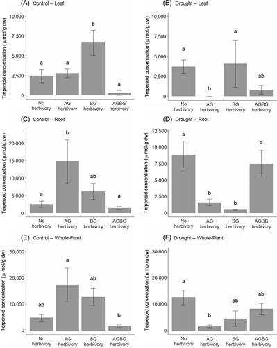

**FIGURE 3**

Leaf, root and the whole-plant terpenoid concentrations (µmol/g dw) under variable water availability (control and drought) and herbivory (aboveground (AG), belowground (BG), simultaneous (AGBG) and no-herbivory) treatments. Whole-plant is represented by the sum of leaf and root concentrations. Bars represent means and vertical black lines indicate the standard error. Different letters indicate significant differences among herbivory treatments (*p* < 0.05) based on post hoc Tukey's tests

### 3.5 Herbivory

All plants exposed to belowground herbivores (BG and AGBG) were successfully infected by the nematode *M. incognita* (number of galls overall mean ± *SE*: 13.94 ± 2.91), and 99% of the plants had leaf damage cumulative leftover following the consecutive caterpillar herbivory. Infection (number of galls/g of root) and leftover damage were similar between water treatments (*F*<sub>1,31</sub> = 0.076, *p* = 0.78; *F*<sub>1,39</sub> = 2.44, *p* = 0.13; respectively; Figure 4). Under control water, infection of plants in the BG treatment was higher than in AGBG treatment plants (*F*<sub>1,16</sub> = 5.128, *p* < 0.04; Figure 4A), and plants exposed to AG herbivory had five times more leftover damage than those in the AGBG treatment (*F*<sub>1,17</sub> = 24.28, *p* < 0.001; Figure 4B). Under drought, infection was similar between herbivory treatments (*F*<sub>1,13</sub> = 0.0001, *p* = 0.99; Figure 4), but leftover damage was 2.3 times higher in AG plants than in those exposed to AGBG herbivory (*F*<sub>1,20</sub> = 5.66, *p* < 0.03; Figure 4).

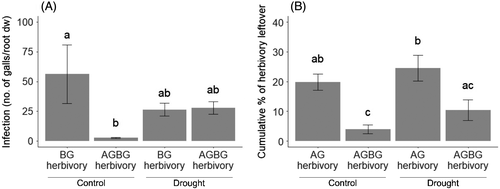

**FIGURE 4**

Nematode infection (number of nematode galls per dry weight of roots) and leaf damage cumulative leftover (summed percentage of caterpillar herbivory over time relative to total leaf area) for each water and herbivory treatment. Bars represent means and vertical black lines indicate the standard error. Different letters indicate significant differences among herbivory treatments (*p* < 0.05) based on post hoc Tukey's tests

## 4 DISCUSSION

For decades it has been argued that fast-growing plants in resource-rich environments should have greater tolerance of herbivory (see Nunez-Farfan et al., 2007; Strauss & Agrawal, 1999). Our results with a fast-growing species reveal that this predicted high tolerance and investment in defence are context-dependent in ways that only become apparent when expanding to consider belowground processes. Under moderate drought stress (30% reduction) plant responses were rapid and elastic, as plants produced defences while also sometimes overcompensating in growth. However, the capacity of plants to grow or produce terpenoids in drought conditions was associated with nematode infection rates. Taking a ‘whole-plant’ approach, including the ecologically realistic situation of simultaneous above- and belowground herbivory, allowed us to demonstrate that belowground herbivory is a primary driver of tolerance under limited water conditions.

Simultaneous herbivory by caterpillars and nematodes had consistent effects on both leaf and root chemistry regardless of water limitation. However, the independent effects of these herbivores were more complex. Root feeders led to increased concentrations of terpenoids in leaves relative to controls under non-limiting water, but decreased concentrations in roots when water was limiting. Similarly, foliar herbivory resulted in increased terpenoid concentrations in roots under control water, but decreased concentrations in both roots and leaves under drought. This indicates that plant responses to herbivory are context-dependent. When attacked in a single compartment (i.e. leaves or roots), they can regrow the attacked tissue while reinforcing defences in the non-attacked compartment (Mundim et al., 2017) under control water. However, when attacked in leaves and roots simultaneously, something common in natural settings, they can regrow the attacked tissue in both compartments while severely decreasing defence production in leaves regardless of water conditions, and in roots under control water. It is important to note, however, that the increased root terpenoid concentration under limiting water is likely due to drought effects on specific terpene synthesis, and could reflect an acclimation to this stress (e.g. Kleiber et al., 2017; Selmar & Kleinwächter, 2013). A more mechanistic understanding of tolerance and resistance to herbivory will require studies manipulating both the location and intensity of herbivore feeding as well as resource availability over multiple plant generations.

Despite decades of theoretical and empirical attention, a clear understanding of how resource availability influences the costs and benefits of tolerance has proven elusive.

Reduced resource availability is predicted to decrease tolerance and performance, especially when the limiting resources are obtained primarily via roots. We found that whole-plant biomass gain was independent of water availability. Simultaneously attacked plants under drought did not have decreased tolerance compared to those under control water. *Solanum* species are very resilient and adapted to growth and development in unfavourable habitat conditions such as water stress or acidic and nutrient-poor soils (Vidal et al., 1999). Thus, this pattern could have resulted from a potential inefficacy of the water variation treatment. We based the 30% water reduction on IPCC estimates for precipitation variation in the next decade, which could have been insufficient and thus rendered the decreased water level unable to affect plant response patterns. However, we detected strong negative effects of water limitation on root complexity and positive effects on total terpenoid concentration, indicating the efficacy of the treatment in eliciting plant responses. Therefore, our results highlight that to some extent, there is a nonlinear cost to benefit function to invest in tolerance due to limiting resources. Although the plant invests in tolerance and resistance even in low water levels, it is reasonable to assume that the pressure of being attacked in more than one part at the same time elicits a strong expression of tolerance regardless of the environmental limitation.

Our findings have important implications for the understanding of plant responses to herbivory and the improvement of theoretical frameworks for the study of plant tolerance. For example, the limiting resource model (Wise & Abrahamson, 2005) has been an important addition to the field of plant–herbivore interactions by synthesizing and streamlining information from multiple previous models of trade-offs between tolerance and resistance in a flexible and general framework. We suggest generalizing the model to account for the realistic condition of simultaneous attacks of roots and leaves, herbivore identity, herbivore specialization (also see Gao et al., 2008), herbivory intensity, as well as the potential for whole-plant responses. In addition, there is mounting evidence suggesting that simultaneous allocation of resources to tolerance and resistance are prevalent among plants (e.g. Mundim et al., 2017; Nunez-Farfan et al., 2007; Pilson, 2000). We therefore suggest that future studies should focus on further elaborating the evolutionary ecology of whole-plant tolerance-resistance responses in variable environmental conditions. We argue that only a whole-plant perspective can provide complete and general answers for open questions such as whether tolerance is an evolutionarily stable strategy or how much investment in tolerance is possible before suffering negative consequences. In fact, without considering whole-plant responses, the mechanisms underpinning the evolution of tolerance and resistance under limiting resource conditions would likely be very different and potentially misleading.

## ACKNOWLEDGEMENTS

We thank M. A. Santos and the Nematology Research Lab at the Federal University of Uberlandia for providing nematode eggs. We also thank the editors and reviewers for comments and suggestions that improved this manuscript. During this study, F. Mundim and E. Vieira-Neto were supported by assistantships from the UF College of Agricultural and Life Sciences and Fellowships from Brazil's Science without Borders Program (Projects 237960/2012-5 and 202012/2012-3). E. Bruna was supported by a Special Visiting Researcher Fellowship from the Science without Borders Program (Project 061/2012).

## AUTHORS' CONTRIBUTIONS

F.M.M. and E.M.B. conceived the ideas and designed the methodology; F.M.M., E.H.M.V.-N. and H.A. collected the data; F.M.M., E.H.M.V.-N. and E.M.B. contributed to writing the manuscript. All authors contributed to the analyses and interpretation of data, critically contributed to the drafts and gave final approval for publication.

July 2021

Pages 2729-2739

  [Juan Fornoni](https://besjournals.onlinelibrary.wiley.com/action/doSearch?ContribAuthorRaw=Fornoni%2C+Juan),

  [Journal of Ecology](https://besjournals.onlinelibrary.wiley.com/journal/13652745)